# PostMates Delivery Analysis

Chris Gunderson

26 June, 2022

## Project Overview

Between 3/9/2019 and 3/21/2020, I recorded my PostMates delivery data while living in Denver, CO. My goal was to examine basic descriptive statistics (e.g., mean per hour earnings) and visualize my earnings by each day of the week, the most likely to time to pick up orders (when it is busiest), the average distance I would drive from a delivery location to a customer, and how many deliveries I would typically make per hour..

## Load packages

```r
library(tidyverse)
library(tidytext)
library(readxl)
library(lubridate)
library(hms)
library(scales)
library(gmodels) # for confidence intervals
library(Hmisc)
library(effsize)
```

## Load data

I kept track of three different sets of related data. In `PM_Earnings.xlsx`, I notated when and where I delivered from, the type of location (e.g., Fast Food), base pay, tips, mileage, and how long the order took to receive. `PM_GuaranteedEarning.xlsx` kept track of instances when I made enough deliveries in a specific time period to earn a guaranteed amount of money. `PM_HoursMileage.xlsx` documents how long I spent during a driving session and the total miles driven.

```r
Deliveries <- read_xlsx('PM_Earnings.xlsx')

GuaranteedEarnings <- read_xlsx('PM_GuaranteedEarning.xlsx')

HoursMileage <- read_xlsx('PM_HoursMileage.xlsx')
```

## Adjust data and add new variables

```r
# Deliveries: add time, weekday names

DelivData <- Deliveries %>%
  mutate(PickUpTime = as_hms(Date_Time),
         WeekdayName = wday(Weekday, label = T)) %>%
  as_tibble()

# Guaranteed earnings

GE <- GuaranteedEarnings %>%
  mutate(WeekdayName = wday(Weekday, label = T)) %>%
  as_tibble()

# Hours and Mileage

HM <- HoursMileage %>%
  mutate(
    WeekdayName = wday(Weekday, label = T),
    HoursWorked = ((3600 * Hours) + (60 * Minutes) + Seconds) / 3600
  ) %>%
  as_tibble()
```

## Data Wrangling

First, I needed to wrangle and combine the data to generate basic descriptive statistics.

```r
# Dataset 1: deliveries and earnings

DelivCompressed <- DelivData %>%
  select(Date, PMEarnings, NumDelivery, WeekdayName) %>%
  group_by(Date, WeekdayName) %>%
  summarise(
    SumEarnings = sum(PMEarnings, na.rm = T),
    TotalDeliveries = sum(NumDelivery, na.rm = T)
  ) %>%
  select(Date, WeekdayName, TotalDeliveries, SumEarnings) %>%
  arrange(desc(Date)) %>%
  as_tibble()

#Dataset 2: hours worked and mileage

HM2 <- HM %>%
  select(Date, WeekdayName, HoursWorked, TotalMiles)

#Dataset 3: Combine them!

Combined <- left_join(DelivCompressed,
                      HM2,
                      by = c("Date" = "Date",
                             "WeekdayName" = "WeekdayName")) %>%
  mutate(PerHrEarning = SumEarnings / HoursWorked) %>%
  mutate(DeliveriesPerHour = TotalDeliveries/HoursWorked) %>%
  as_tibble()

# Tip ratio
# TipRatio <- Deliveries %>%
#   select(TipYesNo) %>%
#   summarize(MyTipRatio = round(mean(TipYesNo)))

# Calculate average number of deliveries per night
AvgDelivPerSession <- Deliveries %>%
  group_by(Session) %>%
  summarise(sum1 = sum(NumDelivery, na.rm = T)) %>%
  summarise(sum1 = mean(sum1))

# Calulate the number of unique locations
LocationName <- c(Deliveries$Loc1,
                  Deliveries$Loc2,
                  Deliveries$Loc3,
                  Deliveries$Loc4,
                  Deliveries$Loc5)
UniqueLocations <- length(unique(LocationName))

# Weekly summary of earnings
WeeklySummary <- Combined %>%
  select(-WeekdayName) %>%
  group_by(week(Date)) %>%
  summarise(
    AllDeliveries = sum(TotalDeliveries),
    AllHours = sum(HoursWorked),
    WeeklyEarning = sum(SumEarnings)
  )

#95% CI for per hr earning
perhr_CI <- ci(Combined$PerHrEarning)

#95% CI for tip frequency
TipSuccess <- Deliveries %>%
  select(TipYesNo) %>%
  filter(TipYesNo == 1) %>%
  count()

TipOpportunities <- Deliveries %>%
  select(TipYesNo) %>%
  count()

TipCI <- binconf(x = TipSuccess$n,
                 n = TipOpportunities$n)

# How often to I get the guaranteed earnings?
Data1 <- Combined %>%
  mutate(WeekdayName = as.character(WeekdayName)) %>%
  filter(WeekdayName == "Fri" |
           WeekdayName == "Sat" |
           WeekdayName == "Sun") %>%
  select(Date, WeekdayName, SumEarnings)

Data2 <- GE %>%
  mutate(WeekdayName = as.character(WeekdayName)) %>%
  select(Date, WeekdayName, GEEarnings)

Data3 <- right_join(Data2, Data1,
                    by = 'Date', 'WeekdayName') %>%
  mutate(GE_Achieved = if_else(GEEarnings > 0, 1, 0),
         GE_Achieved = replace_na(GE_Achieved, 0)) %>%
  rename(WeekdayName = WeekdayName.x,
         PMEarnings = SumEarnings) %>%
  select(Date, WeekdayName, PMEarnings, GEEarnings, GE_Achieved) %>%
  mutate(WeekdayName = wday(Date, label = T)) %>%
  arrange(Date) %>%
  as_tibble() %>%
  mutate(GEEarnings = replace_na(GEEarnings, 0),
         TotalEarnings = PMEarnings + GEEarnings)

Data4 <- left_join(Data3,
                      HM2,
                      by = c("Date" = "Date",
                             "WeekdayName" = "WeekdayName")) %>%
  mutate(PerHrEarning = TotalEarnings / HoursWorked)

#95% CI for guaranteed earnings frequency
GE_A <- Data3 %>%
  select(GE_Achieved) %>%
  filter(GE_Achieved == 1) %>%
  count()

GE_Oppor <- Data3 %>%
  select(GE_Achieved) %>%
  count()

GE_CI <- binconf(x = GE_A$n,
                 n = GE_Oppor$n)

#Per session sum earning
Sesssion_Earning_CI <- ci(Combined$SumEarnings)

#How many hours do I average per session
HoursWorkedPerSession <- Combined %>%
  group_by(week(Date)) %>%
  summarise(Sum_hrs = sum(HoursWorked))
```

## Basic income statistics

Next, I wanted a nicely formatted output of descriptive statistics. This gives me a quick overview of the number of sessions, deliveries, locations, earnings, hours worked, and miles driven.

```r
cat(
  "\nNumber of sessions =",
  max(DelivData$Session),
  "\nNumber of deliveries =",
  sum(DelivData$NumDelivery, na.rm = T),
  "\nNumber of unique locations =",
  UniqueLocations,
  "\n",
  "\nBase pay earnings =",
  sum(DelivData$BasePay, na.rm = T),
  "\nTip earnings =",
  sum(DelivData$Tip, na.rm = T),
  "\n",
  "\nGuaranteed earnings =",
  sum(GE$GEEarnings, na.rm = T),
  "\n",
  "\nTotal earnings =",
  (
    sum(DelivData$PMEarnings, na.rm = T) + sum(GE$GEEarnings, na.rm = T)
  ),
  "\n",
  "\nTip frequency =",
  round(TipCI[1], 2),
  "\nTip frequency 95% CI lower bound = ",
  round(TipCI[2], 2),
  "\nTip frequency 95% CI upper bound = ",
  round(TipCI[3], 2),
  "\n",
  "\nGuaranteed earnings frequency estimate = ",
  round(mean(GE_CI[1]), 2),
  "\nGuaranteed earnings 95% CI lower bound = ",
  round(mean(GE_CI[2]), 2),
  "\nGuaranteed earnings 95% CI upper bound = ",
  round(mean(GE_CI[3]), 2),
  "\n",
  "\nPer hour earning estimate =",
  (round(mean(
    Combined$PerHrEarning
  ), 2)),
  "\nPer hour earning 95% CI lower bound = ",
  round(perhr_CI[2], 2),
  "\nPer hour earning 95% CI upper bound = ",
  round(perhr_CI[3], 2),
  "\n",
  "\nAverage earning per session = ",
  round(Sesssion_Earning_CI[1], 2),
  "\nAverage earning per session 95% CI lower bound = ",
  round(Sesssion_Earning_CI[2], 2),
  "\nAverage earning per session 95% CI upper bound = ",
  round(Sesssion_Earning_CI[3], 2),
  "\n",
  "\nAverage weekly earning = ",
  round(mean(WeeklySummary$WeeklyEarning), 2),
  "\nAverage weekly number of deliveries = ",
  round(mean(WeeklySummary$AllDeliveries), 0),
  "\nAverage weekly number of hours worked = ",
  round(mean(HoursWorkedPerSession$Sum_hrs), 2),
  "\n",
  "\nTotal number of hours worked =",
  round(sum(HM$HoursWorked), 2),
  "\nTotal miles driven =",
  sum(HM$TotalMiles)
)
```

```
##
## Number of sessions = 93
## Number of deliveries = 718
## Number of unique locations = 264
##
## Base pay earnings = 3286.8
## Tip earnings = 3099.58
##
## Guaranteed earnings = 512.94
##
## Total earnings = 6899.32
##
## Tip frequency = 0.79
## Tip frequency 95% CI lower bound =  0.75
## Tip frequency 95% CI upper bound =  0.82
##
## Guaranteed earnings frequency estimate =  0.52
## Guaranteed earnings 95% CI lower bound =  0.4
## Guaranteed earnings 95% CI upper bound =  0.64
##
## Per hour earning estimate = 19.27
## Per hour earning 95% CI lower bound =  18.25
## Per hour earning 95% CI upper bound =  20.29
##
## Average earning per session =  68.67
## Average earning per session 95% CI lower bound =  63.48
## Average earning per session 95% CI upper bound =  73.86
##
## Average weekly earning =  172.6
## Average weekly number of deliveries =  19
## Average weekly number of hours worked =  8.98
##
## Total number of hours worked = 332.43
## Total miles driven = 4602.65
```

## Earnings per month

I group and calculate earnings by month for each month I did PostMates deliveries.

```r
# Earnings from deliveries

DeliveryEarnings <- DelivData %>%
  select(Date, WeekdayName, NumDelivery, PMEarnings) %>%
  group_by(Date, WeekdayName) %>%
  summarise(
    DeliveryEarning = sum(PMEarnings, na.rm = T),
    TotalDeliveries = sum(NumDelivery, na.rm = T)
  )

#Earnings from guaranteed earnings

GE_Earnings <- GE %>%
  select(Date, WeekdayName, GEEarnings)

#joined dataset

Delivery_and_Guaranteed <- left_join(DeliveryEarnings, GE_Earnings,
                                     by = c("Date", "WeekdayName")) %>%
  replace(., is.na(.), 0) %>%
  summarise(
    TotalEarnings = (DeliveryEarning + GEEarnings),
    TotalDeliveries = sum(TotalDeliveries)
  )

#summarize earnings by month

EarningsPerMonth <- Delivery_and_Guaranteed %>%
  mutate(Month = month(Date, label = T),
         Year = year(Date)) %>%
  group_by(Year, Month) %>%
  summarise(
    MonthlyEarning = sum(TotalEarnings),
    TotalDeliveries = sum(TotalDeliveries),
    Mean_Per_Delivery = (MonthlyEarning/TotalDeliveries)
  )
EarningsPerMonth
```

```
## # A tibble: 13 × 5
## # Groups:   Year [2]
##     Year Month MonthlyEarning TotalDeliveries Mean_Per_Delivery
##    <dbl> <ord>          <dbl>           <dbl>             <dbl>
##  1  2019 Mar             442.              45              9.83
##  2  2019 Apr            1132.             117              9.68
##  3  2019 May             305.              32              9.54
##  4  2019 Jun             304.              31              9.82
##  5  2019 Jul            1262.             143              8.82
##  6  2019 Aug             667.              65             10.3
##  7  2019 Sep             776.              81              9.58
##  8  2019 Oct             360.              36              9.99
##  9  2019 Nov             420.              39             10.8
## 10  2019 Dec             154.              19              8.11
## 11  2020 Jan             393.              45              8.72
## 12  2020 Feb             376.              37             10.2
## 13  2020 Mar             307.              28             11.0
```

## Earnings per week

I also examined how much I made per week, how many hours I worked, and how many deliveries I made.

```r
WeeklySummary <- Combined %>%
  select(-WeekdayName) %>%
  mutate(Month = month(Date, label = T),
         Year = year(Date)) %>%
  group_by(Year, week(Date), Month) %>%
  summarise(
    Deliveries = sum(TotalDeliveries),
    HoursWorked = sum(HoursWorked),
    WeeklyEarning = sum(SumEarnings)
  ) %>%
  rename(WeekOfYear = `week(Date)`)
WeeklySummary %>% print(n = 200)
```

```
## # A tibble: 41 × 6
## # Groups:   Year, WeekOfYear [39]
##     Year WeekOfYear Month Deliveries HoursWorked WeeklyEarning
##    <dbl>      <dbl> <ord>      <dbl>       <dbl>         <dbl>
##  1  2019         10 Mar           18        8.54         162.
##  2  2019         11 Mar           21       10.4          186.
##  3  2019         13 Mar            6        5.20          56.8
##  4  2019         14 Apr           30       16.2          232.
##  5  2019         15 Apr           30       14.4          255.
##  6  2019         16 Apr           30       12.1          225.
##  7  2019         17 Apr           27       12.9          231.
##  8  2019         19 May            9        4.17         117.
##  9  2019         20 May            6        3.85          41.2
## 10  2019         21 May           17        8.48         126.
## 11  2019         22 Jun            9        3.89          85.0
```

[output cut: 30 more lines]

## How much do I make for a single delivery?

After making many deliveries, I wanted to know how much I made for a single delivery. This excludes ‘stacked’ deliveries, where I picked up an several orders from one location, or picked up several deliveries from more than one location before making deliveries to customers.

```r
OneDelivery <- Deliveries %>%
  filter(NumDelivery == 1) %>%
  summarise(
    n = n(),
    Mean_Per_Delivery = round(mean(PMEarnings, na.rm = T), 2),
    Mean_Base_Pay = round(mean(BasePay, na.rm = T), 2),
    Mean_Tip = round(mean(Tip, na.rm = T), 2)
  )
OneDelivery
```

```
## # A tibble: 1 × 4
##       n Mean_Per_Delivery Mean_Base_Pay Mean_Tip
##   <int>             <dbl>         <dbl>    <dbl>
## 1   395              9.52           5.2      5.5
```

## How much do I make on ‘stacked’ deliveries?

Occasionally, I made ‘stacked’ deliveries, as described above. Here, I wanted descriptive statistics on how much I made for making stacked deliveries. `NumDelivery` indicates the number of items I picked up (from one or more locations) before making deliveries to customers.

```r
StackedDelivery <- Deliveries %>%
  filter(NumDelivery > 1) %>%
  group_by(NumDelivery) %>%
  summarise(
    n = n(),
    Mean_Per_Delivery = round(mean(PMEarnings, na.rm = T), 2),
    Mean_Base_Pay = round(mean(BasePay, na.rm = T), 2),
    Mean_Tip = round(mean(Tip, na.rm = T), 2)
  )
StackedDelivery
```

```
## # A tibble: 4 × 5
##   NumDelivery     n Mean_Per_Delivery Mean_Base_Pay Mean_Tip
##         <dbl> <int>             <dbl>         <dbl>    <dbl>
## 1           2    95              17.1          7.96     9.54
## 2           3    30              21.5          9.67    12.2
## 3           4     7              33.7         18.1     15.6
## 4           5     3              39.7         20.2     19.5
```

## Per hour earning by day of the week

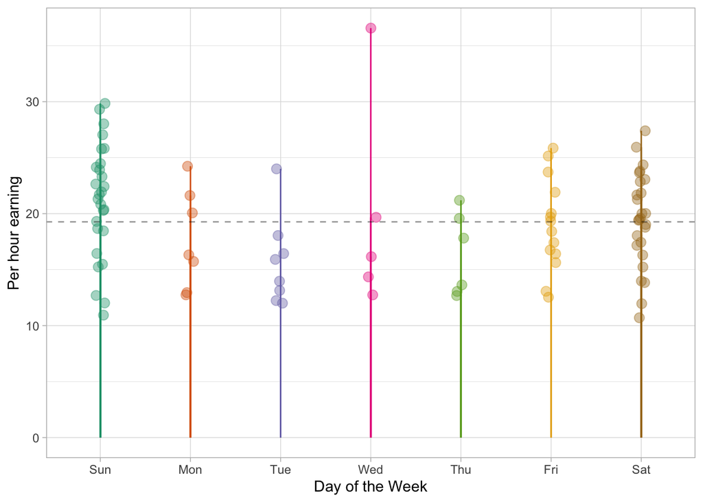

```r
ggplot(Combined, aes(x= WeekdayName, y= PerHrEarning)) +
  geom_jitter(size = 3,
              width = .06,
              alpha = 0.4,
              aes(color = WeekdayName),
              show.legend = FALSE) +
  geom_segment(aes(x = WeekdayName,
                   xend = WeekdayName,
                   y = 0,
                   yend = PerHrEarning,
                   color = WeekdayName),
               show.legend = FALSE) +
  geom_hline(aes(yintercept = mean(PerHrEarning)),
             linetype = "dashed",
             color = "black",
             alpha = .4) +
  labs(x = "Day of the Week",
       y = "Per hour earning") +
  scale_colour_brewer(palette = "Dark2") +
  theme_light()
```

## What are my most frequent delivery locations and their tip ratio?

Since I had a sufficient amount of unique locations that I delivered from, I wanted to find out which locations I deliver from most frequently, and how often I received a tip from doing those deliveries (`TipRatio`). For example, I made 70 deliveries from Shake Shack and received a tip 91% of the time.

```r
LocationName <- c(Deliveries$Loc1,
                  Deliveries$Loc2,
                  Deliveries$Loc3,
                  Deliveries$Loc4,
                  Deliveries$Loc5)

LocationNumber <- c(Deliveries$Loc1_Num,
                    Deliveries$Loc2_Num,
                    Deliveries$Loc3_Num,
                    Deliveries$Loc4_Num,
                    Deliveries$Loc5_Num)

LocationTip <- c(Deliveries$TipYesNo,
                 Deliveries$TipYesNo,
                 Deliveries$TipYesNo,
                 Deliveries$TipYesNo,
                 Deliveries$TipYesNo)

MyLocations <- as_tibble(cbind(LocationName,
                               LocationNumber))

MyLocationTips <- as_tibble(cbind(LocationName,
                                  LocationTip))

MyLocations$LocationNumber <- as.numeric(LocationNumber)

MyLocationTips$LocationTip <- as.numeric(LocationTip)


MyTopLocations <- MyLocations %>%
  group_by(LocationName) %>%
  summarise(Deliveries = sum(LocationNumber, na.rm = T))

TipRatios <- MyLocationTips %>%
  group_by(LocationName) %>%
  summarise(TipRatio = round(mean(LocationTip, na.rm = T), 2))

LocsAndRatios <- inner_join(TipRatios, MyTopLocations,
                            by = "LocationName") %>%
  select(LocationName, Deliveries, TipRatio) %>%
  arrange(desc(Deliveries), desc(TipRatio))
print(LocsAndRatios, n = 12)
```

```
## # A tibble: 264 × 3
##    LocationName         Deliveries TipRatio
##    <chr>                     <dbl>    <dbl>
##  1 ShakeShack                   70     0.91
##  2 Uncle                        28     1
##  3 ThaiMonkeyClub               21     0.82
##  4 ChipotleMexicanGrill         19     0.75
##  5 LittleIndia                  17     0.71
##  6 HealthyAsianGarden           13     0.89
##  7 ThaiBasil                    11     1
##  8 MoesBBQ                      10     1
##  9 PizzeriaLocale               10     1
## 10 CornerRamen                  10     0.88
## 11 FontanaSushi                 10     0.75
## 12 7-Eleven                     10     0.4
## # … with 252 more rows
```

## Where have I made the most money?

It may also be advantagous or efficient to know which places resulted in the highest earnings. In this case, Shake Shack was at the top. I also calculated `VisitEarningRatio`, which is the mean earning per visit.

```r
LocationName <- c(Deliveries$Loc1,
                  Deliveries$Loc2,
                  Deliveries$Loc3,
                  Deliveries$Loc4,
                  Deliveries$Loc5)

LocationNumber <- c(Deliveries$Loc1_Num,
                    Deliveries$Loc2_Num,
                    Deliveries$Loc3_Num,
                    Deliveries$Loc4_Num,
                    Deliveries$Loc5_Num)

LocationEarnings <- c(Deliveries$PMEarnings,
                      Deliveries$PMEarnings,
                      Deliveries$PMEarnings,
                      Deliveries$PMEarnings,
                      Deliveries$PMEarnings)

MyLocations <- as_tibble(cbind(LocationName,
                               LocationNumber))

MyLocationEarnings <- as_tibble(cbind(LocationName,
                                      LocationEarnings))

MyLocationEarnings$LocationNumber <- as.numeric(LocationNumber)

MyLocationEarnings$LocationEarnings <- as.numeric(LocationEarnings)


MyTopLocationEarnings <- MyLocationEarnings %>%
  group_by(LocationName) %>%
  summarise(
    Earnings = sum(LocationEarnings, na.rm = T),
    Visits = n(),
    VisitEarningRatio = round((Earnings / Visits), 2)
  ) %>%
  drop_na() %>%
  arrange(desc(Earnings),
          desc(Visits),
          desc(VisitEarningRatio))

MyTopLocationEarnings
```

```
## # A tibble: 263 × 4
##    LocationName         Earnings Visits VisitEarningRatio
##    <chr>                   <dbl>  <int>             <dbl>
##  1 ShakeShack               554.     36             15.4
##  2 Uncle                    339.     15             22.6
##  3 ThaiMonkeyClub           255.     17             15.0
##  4 LittleIndia              187.     14             13.4
##  5 CornerRamen              185.      8             23.2
##  6 PizzeriaLocale           167.      8             20.8
##  7 ChipotleMexicanGrill     149.     16              9.34
##  8 IzuSushi                 131.      6             21.9
##  9 HealthyAsianGarden       130.      9             14.4
## 10 FontanaSushi             106.      8             13.3
## # … with 253 more rows
```

## These places don’t as tip well (after at least 3 deliveries)

Some places do not tip as well. I first excluded any places I delivered from only once or twice, and then examined the data. After making 10 deliveries from 7-Eleven, my tip ratio was only 40%.

```r
BadTipRatio <- LocsAndRatios %>%
  filter(Deliveries >= 3) %>%
  filter(TipRatio <= 0.5) %>%
  arrange(desc(Deliveries), TipRatio)

print(BadTipRatio, n = 10)
```

```
## # A tibble: 7 × 3
##   LocationName              Deliveries TipRatio
##   <chr>                          <dbl>    <dbl>
## 1 7-Eleven                          10     0.4
## 2 FiveGuysBurgersandFries            8     0.5
## 3 ChopShopCasualUrbanEatery          5     0.33
## 4 Wendys                             4     0.25
## 5 FatShackDU                         3     0.33
## 6 PandaExpress                       3     0.33
## 7 SonicDriveIn                       3     0.33
```

## What places always tip (after at least 5 deliveries)?

Likewise, it would be advantageous to know if there are any locations that tip 100% of the time. I excluded any locations that I made fewer than 5 deliveries from. After delivering from Uncle 28 times, I always got a tip.

```r
AlwaysTip <- LocsAndRatios %>%
  filter(Deliveries >= 5) %>%
  filter(TipRatio == 1.0) %>%
  arrange(desc(Deliveries))

print(AlwaysTip, n = 20)
```

```
## # A tibble: 12 × 3
##    LocationName             Deliveries TipRatio
##    <chr>                         <dbl>    <dbl>
##  1 Uncle                            28        1
##  2 ThaiBasil                        11        1
##  3 MoesBBQ                          10        1
##  4 PizzeriaLocale                   10        1
##  5 GrillinWings                      8        1
##  6 JerusalemRestaurant               7        1
##  7 CafeByblosGreek&Lebanese          6        1
##  8 IzuSushi                          6        1
##  9 PeiWeiAsianKitchen                6        1
## 10 TonyPsBarPizzeria                 6        1
## 11 NorthItalia                       5        1
## 12 WokanoAsianBistro                 5        1
```

## Which places most frequently have stacked orders?

To make driving more efficient, I examined the most common locations I received stacked orders from. Again, this occurs when I pick up several deliveries from one more locations before delivering to the customer.

```r
StackedOrders <- MyLocations %>%
  mutate(
    TripleDeliv = ifelse(LocationNumber == 3,
                         1, 0),
    DoubleDeliv = ifelse(LocationNumber == 2,
                         1, 0),
    SingleDeliv = ifelse(LocationNumber == 1,
                         1, 0)
  ) %>%
  group_by(LocationName) %>%
  summarise(
    Triple = sum(TripleDeliv),
    Double = sum(DoubleDeliv),
    StackedTotal = Triple + Double,
    Single = sum(SingleDeliv)
  ) %>%
  mutate(
    TotalOrders = (Triple * 3) + (Double * 2) + (Single),
    StackedRatio = round((Triple + Double) /
                           (Triple + Double + Single), 2)
  ) %>%
  arrange(
    desc(StackedTotal),
    desc(Triple),
    desc(Double),
    desc(Single),
    desc(TotalOrders),
    desc(StackedRatio)
  ) %>%
  select(LocationName,
         StackedTotal,
         Triple,
         Double,
         Single,
         TotalOrders,
         StackedRatio)
print(StackedOrders, n = 10)
```

```
## # A tibble: 264 × 7
##    LocationName       StackedTotal Triple Double Single TotalOrders StackedRatio
##    <chr>                     <dbl>  <dbl>  <dbl>  <dbl>       <dbl>        <dbl>
##  1 ShakeShack                   25      9     16     11          70         0.69
##  2 Uncle                         9      4      5      6          28         0.6
##  3 ThaiMonkeyClub                4      0      4     13          21         0.24
##  4 HealthyAsianGarden            4      0      4      5          13         0.44
##  5 MoesBBQ                       4      0      4      2          10         0.67
##  6 TonyPsBarPizzeria             3      0      3      0           6         1
##  7 ChipotleMexicanGr…            2      1      1     14          19         0.12
##  8 LittleIndia                   2      1      1     12          17         0.14
##  9 FontanaSushi                  2      0      2      6          10         0.25
## 10 PizzeriaLocale                2      0      2      6          10         0.25
## # … with 254 more rows
```

## What is the most frequent pick up time?

Knowing when to start driving maximizes time spent on deliveries. Here, I plot a histogram, rug plot, and dotted vertical line (represents the mean pick up time) to visualize when I received the most deliveries.

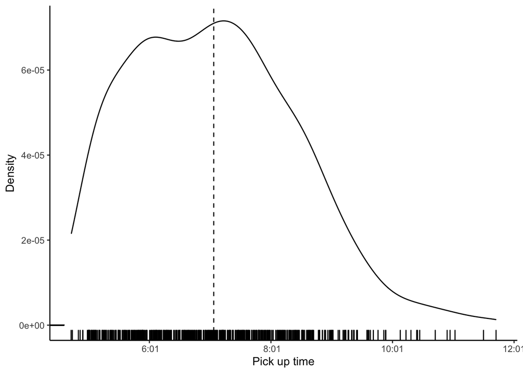

```r
#set lower limit on time, since I've delivered past 12am
lowerlimit <- as_hms("15:00:00")

#filter data by this lower limit
DelivData2 <- DelivData %>%
  filter(PickUpTime >= lowerlimit)

#round the times to the nearest 15 min
TimeData <- DelivData2 %>%
  select(Date_Time, PickUpTime) %>%
  mutate(RoundedPickUps = round_date(Date_Time, unit = "15 mins")) %>%
  mutate(RoundedPickUpTimes = as_hms(RoundedPickUps))

#plot the data
ggplot(TimeData, aes(x = PickUpTime)) +
  geom_density(alpha = 0.5) +
  geom_rug(aes(x = PickUpTime, y = 0),
           position = position_jitter(height = 0)) +
  scale_x_time(labels = time_format("%l:%m")) +
  geom_vline(aes(xintercept = mean(PickUpTime)),
             linetype = "dashed",
             show.legend = FALSE) +
  labs(x = "Pick up time",
       y = "Density") +
  theme_classic()
```

## How long do I wait before I get a new delivery?

```r
# BWDeliv <- DelivData %>%
#   select(Date_Time, Date, Session, WeekdayName, PickUpTime) %>%
#   arrange((Date_Time)) %>%
#   group_by(Session, Date) %>%
#   mutate(myLag = lag(PickUpTime)) %>%
#   mutate(difference = as.duration(PickUpTime - myLag)) %>%
#   mutate(difference2 = (difference / 60)) %>%
#   group_by(Session) %>%
#   summarise(meanWait = mean(difference2, na.rm = T))
#
# # Plot the mean waiting time between deliveries
# ggplot(BWDeliv, aes(meanWait)) +
#   geom_density(alpha = 0.5) +
#   geom_rug(aes(x = meanWait, y = 0),
#            position = position_jitter(height = 0)) +
#   geom_vline(aes(xintercept = mean(meanWait)),
#              linetype = "dashed",
#              show.legend = FALSE) +
#   geom_text(aes(
#     x = mean(meanWait),
#     y = .06,
#     label = round(mean(meanWait))
#   ),
#   hjust = -0.3,
#   size = 3) +
#   labs(x = "Average wait time between deliveries",
#        y = "Density")
```

## Which places have long wait times?

After driving for awhile, it became clear that some places have longer waiting times than others. Knowing which places have long waiting times can help me avoid these locations when I want to maximize the number of deliveries I make per hour.

```r
LocWait <- c(Deliveries$WaitTime_Min,
             Deliveries$WaitTime_Min,
             Deliveries$WaitTime_Min,
             Deliveries$WaitTime_Min,
             Deliveries$WaitTime_Min)

LocWaits <- as_tibble(cbind(LocationName,
                            LocWait))

LocWaits$LocWait <- as.numeric(LocWait)

LocationWaitTimes <- LocWaits %>%
  group_by(LocationName) %>%
  summarise(MeanWait_Min = round(mean(LocWait, na.rm = T)),
            Visits = n()) %>%
  filter(Visits > 2) %>%
  arrange(desc(MeanWait_Min), desc(Visits))
print(LocationWaitTimes, n = 10)
```

```
## # A tibble: 64 × 3
##    LocationName              MeanWait_Min Visits
##    <chr>                            <dbl>  <int>
##  1 ParkBurger                          21      5
##  2 PhoHaus                             16      4
##  3 Uncle                               15     15
##  4 TasteOfThailand                     15      4
##  5 ElNoaNoaMexicanRestaurant           14      3
##  6 LittleOllies                        13      3
##  7 AsukaRamen&Poke                     12      3
##  8 ShakeShack                          11     36
##  9 JackInTheBox                        11      4
## 10 G&BFishandChips                     11      3
## # … with 54 more rows
```

## Average distance from restaurant to drop off

This histogram and rug plot (with a dotted vertical line indicating the mean) indicates how far (in miles) the average distance from the delivery pick up to drop off location was.

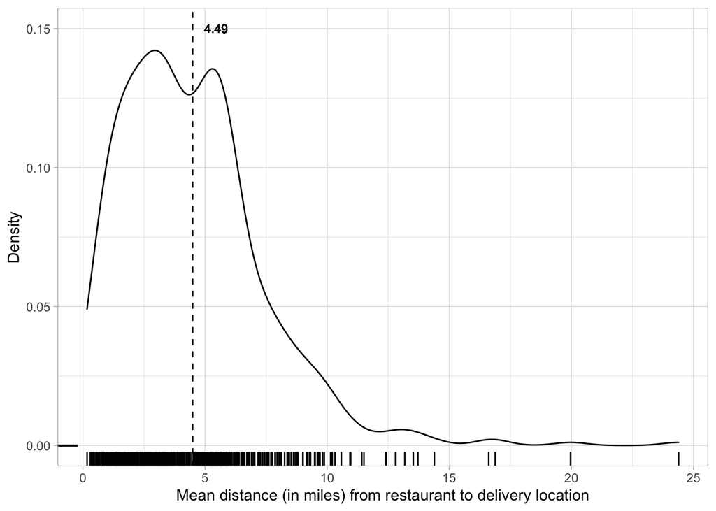

```r
ggplot(DelivData, aes(Distance_MI)) +
  geom_density(alpha = 0.5,
               na.rm = T) +
  geom_rug(aes(x = Distance_MI,
               y = 0),
           position = position_jitter(height = 0)) +
  geom_vline(aes(xintercept = mean(Distance_MI, na.rm = T)),
             linetype = "dashed",
             show.legend = FALSE) +
  geom_text(aes(x = mean(Distance_MI, na.rm = T),
                y = .15,
                label = round(mean(Distance_MI, na.rm = T),2)),
            hjust = -0.5, size = 3) +
  labs(x = "Mean distance (in miles) from restaurant to delivery location",
       y = "Density") +
  theme_light()
```

## Average deliveries per hour

After many deliveries, I wanted to explore how many deliveries I make on average. As indicated in the histogram (and perhaps more clearly with the rug plot), on average I made 2.16 deliveries per hour, but with some variation. As shown above, some locations took longer than others for me to wait for the food. The average deliveries per hour gave me information on what I could expect to earn given a particular time (e.g., 5:00pm-9:00pm, about 8 deliveries)

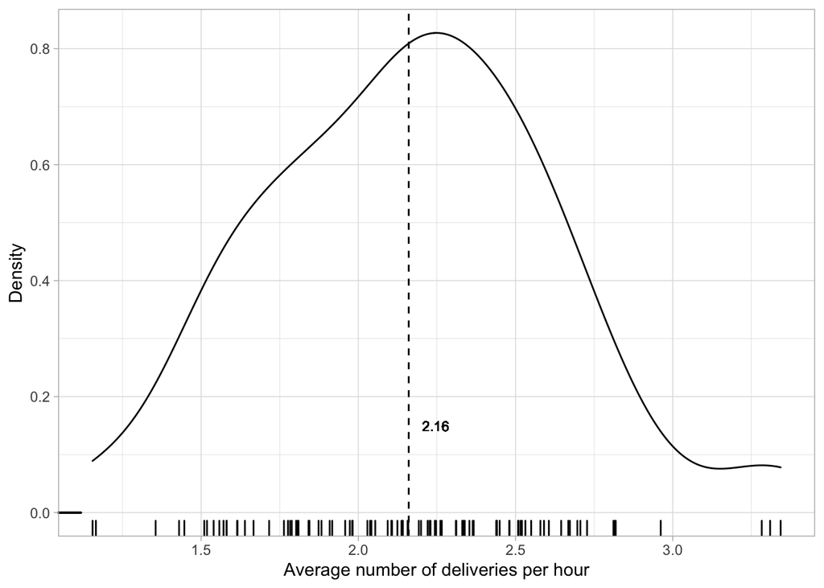

```r
ggplot(Combined, aes(DeliveriesPerHour)) +
  geom_density(alpha = 0.5,
               na.rm = T) +
  geom_rug(aes(x = DeliveriesPerHour,
               y = 0),
           position = position_jitter(height = 0)) +
  geom_vline(aes(xintercept = mean(DeliveriesPerHour, na.rm = T)),
             linetype = "dashed",
             show.legend = FALSE) +
  geom_text(aes(x = mean(DeliveriesPerHour, na.rm = T),
                y = .15,
                label = round(mean(DeliveriesPerHour, na.rm = T),2)),
            hjust = -0.5, size = 3) +
  labs(x = "Average number of deliveries per hour",
       y = "Density") +
  theme_light()
```

## Top 5 best deliveries

Sometimes, I was pleasantly surprised to see I received an excellent tip from a customer. Here, I print my top 5 highest earning deliveries.

```r
Deliveries %>%
  select(Date, Loc1, Loc2, Loc3, Loc4, Loc5, PMEarnings) %>%
  mutate(Date = ymd(Date)) %>%
  arrange(desc(PMEarnings)) %>%
  print(n = 5)
```

```
## # A tibble: 534 × 7
##   Date       Loc1                             Loc2  Loc3  Loc4  Loc5  PMEarnings
##   <date>     <chr>                            <chr> <chr> <chr> <chr>      <dbl>
## 1 2019-08-21 HapaSushiLoDo                    <NA>  <NA>  <NA>  <NA>        59.8
## 2 2019-05-12 LittleOllies                     <NA>  <NA>  <NA>  <NA>        50.9
## 3 2019-10-12 SpiceRoomNeighborhoodIndianBist… <NA>  <NA>  <NA>  <NA>        44.4
## 4 2019-12-01 PizzeriaLocale                   Himc… ElNo… IzuS… Corn…       41.4
## 5 2019-09-14 ElNoaNoaMexicanRestaurant        Litt… Corn… Shak… <NA>        41.2
## # … with 529 more rows
```